# Community composition SynCom

Thoenen et al. BX SynComs

Lisa Thoenen

2025-03-12

# Background

We assembled synthetic bacterial communities (SynCom) from maize root bacteria and grew them with MBOA. At the end of the experiment, we sequenced the communities with amplicon sequencing. The raw data were processed with the DADA2 pipeline. Below we analyse the composition of the SynComs, both on community level and on strain level by mapping the isolates to the ASVs.

# Properties SynCom isolates scheme

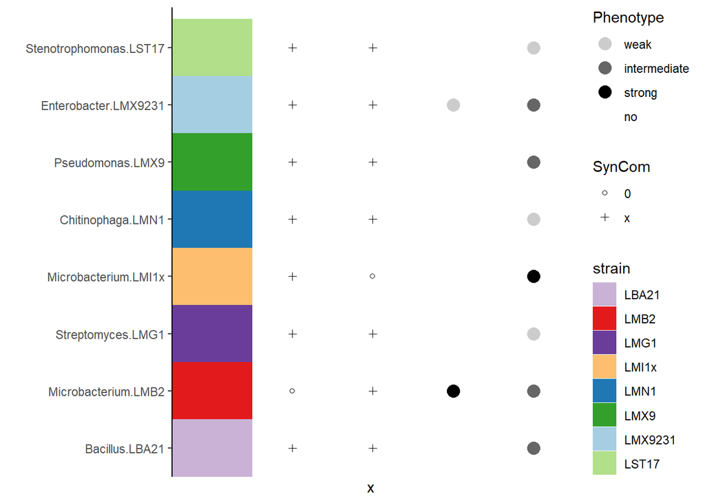

# Explore dataset

*Tree*: Make a tree of the ASVs in the dataset to explore taxonomy

*Taxonomy:* Explore taxonomy of the dataset

# Rarefaction

Check the rarefaction of the data to get an insight into the sequencing depth. Create rarefaction curve.

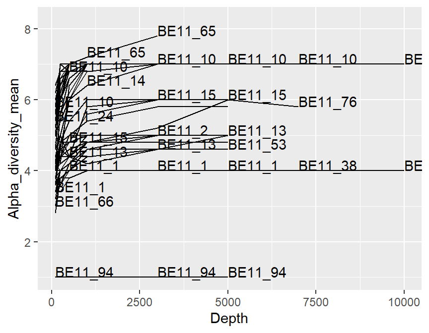

*Metadata*: Combine sequencing data with sample metadata

*Formatting phyloseq object:* - Remove samples from phyloseq - add info sample list to phlyoseq - change barcode names in design file to the same as in the phyloseq - merge design metadata to phyloseq

# Mapping isolates

*normalize abundance with 16s:* Since different bacteria have different amount of 16s rRNA gene copies, we normalize the ASV sequence counts for that. The 16s rRNA copies per strain were estimated from genome sequencing data.

# Compsition in SynCom profiles

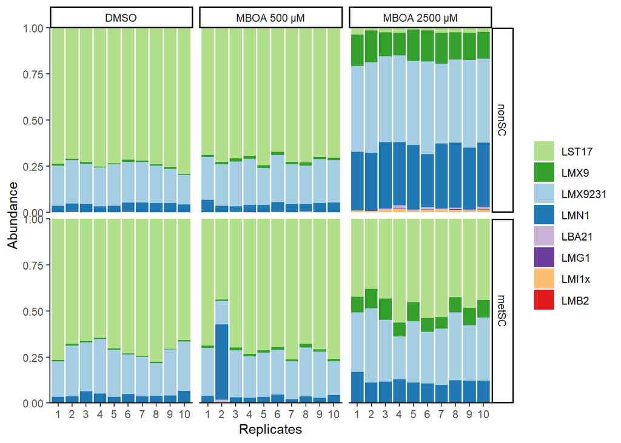

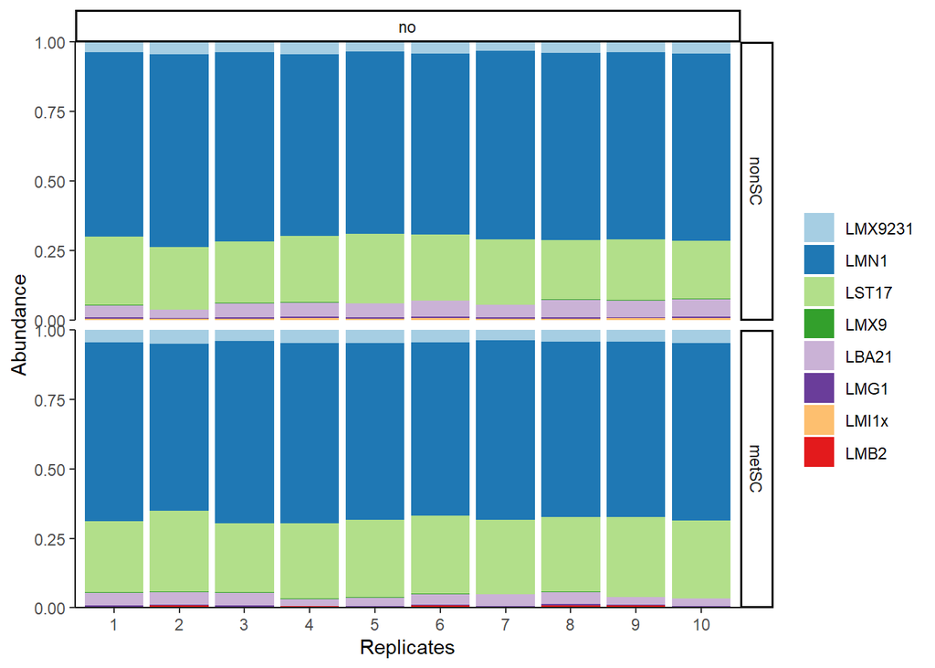

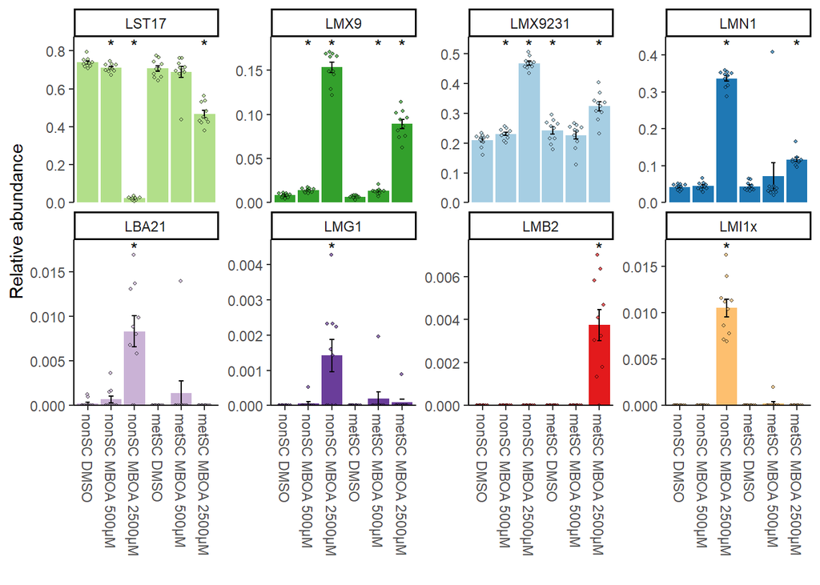

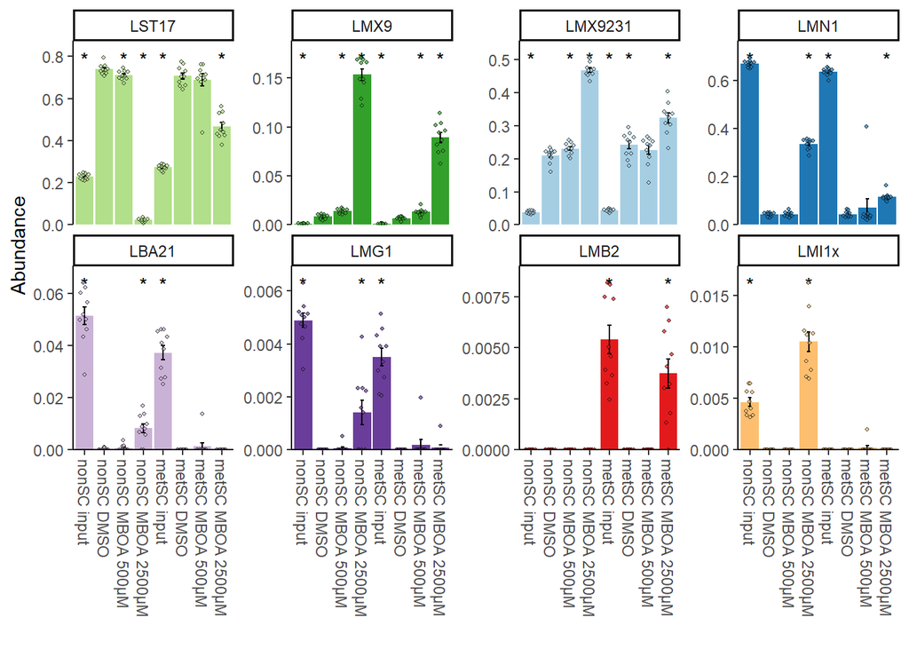

Abundance single strains summary

| groups | Strain | Abundance_norm |
| --- | --- | --- |
| nonSC input | LST17 | 0.2291609 |
| nonSC_DMSO | LST17 | 0.7388196 |
| nonSC_MBOA_500µM | LST17 | 0.7101264 |
| nonSC_MBOA_2500µM | LST17 | 0.0224272 |
| metSC input | LST17 | 0.2729522 |
| metSC_DMSO | LST17 | 0.7070163 |
| metSC_MBOA_500µM | LST17 | 0.6875935 |
| metSC_MBOA_2500µM | LST17 | 0.4671343 |
| nonSC input | LMX9 | 0.0012342 |
| nonSC_DMSO | LMX9 | 0.0082938 |
| nonSC_MBOA_500µM | LMX9 | 0.0141444 |
| nonSC_MBOA_2500µM | LMX9 | 0.1534660 |
| metSC input | LMX9 | 0.0011714 |
| metSC_DMSO | LMX9 | 0.0068126 |
| metSC_MBOA_500µM | LMX9 | 0.0132121 |
| metSC_MBOA_2500µM | LMX9 | 0.0891556 |
| nonSC input | LMX9231 | 0.0382007 |
| nonSC_DMSO | LMX9231 | 0.2097930 |
| nonSC_MBOA_500µM | LMX9231 | 0.2303863 |
| nonSC_MBOA_2500µM | LMX9231 | 0.4675039 |
| metSC input | LMX9231 | 0.0436840 |
| metSC_DMSO | LMX9231 | 0.2416951 |
| metSC_MBOA_500µM | LMX9231 | 0.2260179 |
| metSC_MBOA_2500µM | LMX9231 | 0.3230104 |
| nonSC input | LMN1 | 0.6704803 |
| nonSC_DMSO | LMN1 | 0.0428722 |
| nonSC_MBOA_500µM | LMN1 | 0.0446050 |
| nonSC_MBOA_2500µM | LMN1 | 0.3363332 |
| metSC input | LMN1 | 0.6360078 |
| metSC_DMSO | LMN1 | 0.0444759 |
| metSC_MBOA_500µM | LMN1 | 0.0713873 |
| metSC_MBOA_2500µM | LMN1 | 0.1168689 |
| nonSC input | LBA21 | 0.0513798 |
| nonSC_DMSO | LBA21 | 0.0002214 |
| nonSC_MBOA_500µM | LBA21 | 0.0006852 |
| nonSC_MBOA_2500µM | LBA21 | 0.0083165 |
| metSC input | LBA21 | 0.0372681 |
| metSC_DMSO | LBA21 | 0.0000000 |
| metSC_MBOA_500µM | LBA21 | 0.0013956 |
| metSC_MBOA_2500µM | LBA21 | 0.0000000 |
| nonSC input | LMG1 | 0.0048857 |
| nonSC_DMSO | LMG1 | 0.0000000 |
| nonSC_MBOA_500µM | LMG1 | 0.0000527 |
| nonSC_MBOA_2500µM | LMG1 | 0.0014181 |
| metSC input | LMG1 | 0.0035093 |
| metSC_DMSO | LMG1 | 0.0000000 |
| metSC_MBOA_500µM | LMG1 | 0.0001968 |
| metSC_MBOA_2500µM | LMG1 | 0.0000896 |
| nonSC input | LMB2 | 0.0000000 |
| nonSC_DMSO | LMB2 | 0.0000000 |
| nonSC_MBOA_500µM | LMB2 | 0.0000000 |
| nonSC_MBOA_2500µM | LMB2 | 0.0000000 |
| metSC input | LMB2 | 0.0054072 |
| metSC_DMSO | LMB2 | 0.0000000 |
| metSC_MBOA_500µM | LMB2 | 0.0000000 |
| metSC_MBOA_2500µM | LMB2 | 0.0037412 |
| nonSC input | LMI1x | 0.0046586 |
| nonSC_DMSO | LMI1x | 0.0000000 |
| nonSC_MBOA_500µM | LMI1x | 0.0000000 |
| nonSC_MBOA_2500µM | LMI1x | 0.0105352 |
| metSC input | LMI1x | 0.0000000 |
| metSC_DMSO | LMI1x | 0.0000000 |
| metSC_MBOA_500µM | LMI1x | 0.0001968 |
| metSC_MBOA_2500µM | LMI1x | 0.0000000 |

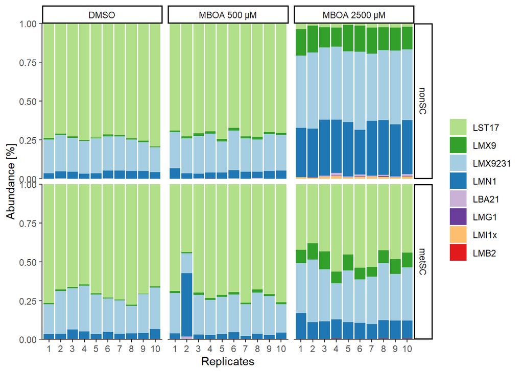

# Composition ordination

## unconstrained ordination

SynComs and inocula in all treatments. Inocula differs strongly from the SynComs. SynCom composition is influenced by treatment, especially by high levels of MBOA.

Both PcoA and CAP show that SynComs grown in high MBOA differ from SynComs grown in low MBOA or DMSO. Further SynCom S and R differ in MBOA high but not in the other treatments.

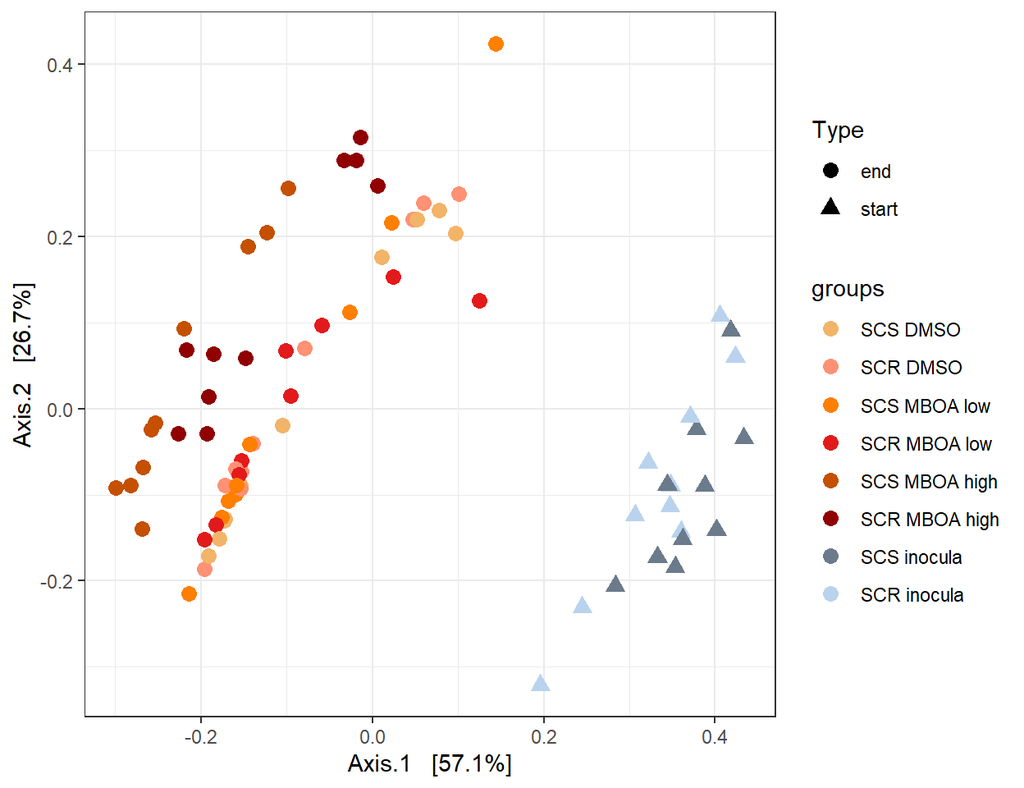

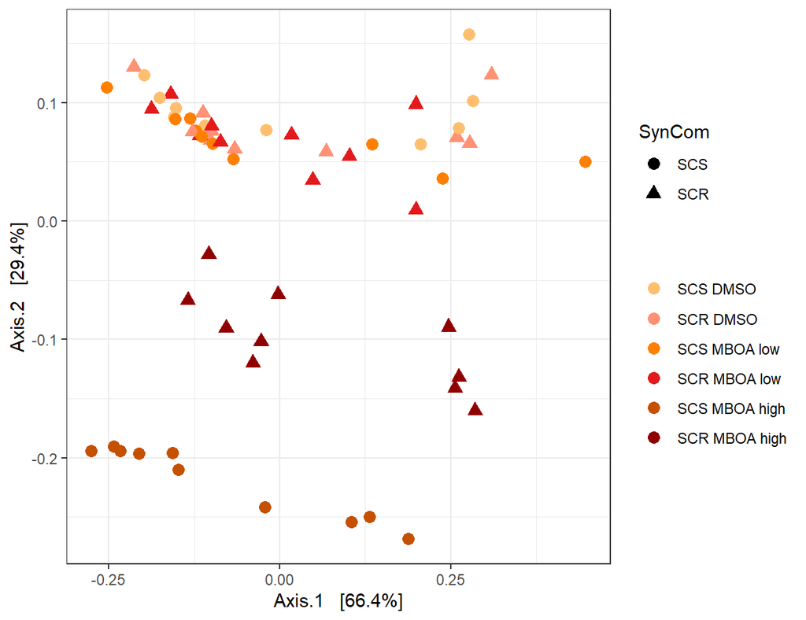

|  | Df | SumOfSqs | F | Pr(>F) |
| --- | --- | --- | --- | --- |
| **Model** | 2 | 0.7919 | 8.413 | 1e-05 |
| **Residual** | 57 | 2.683 | NA | NA |

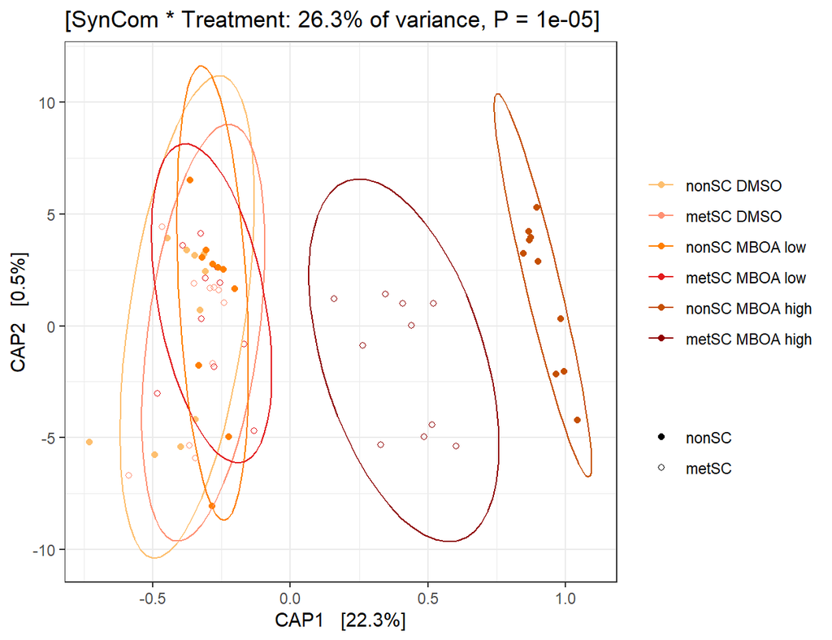

# statistics

using PERMANOVA

All data

|  | Df | SumOfSqs | R2 | F | Pr(>F) |
| --- | --- | --- | --- | --- | --- |
| Treatment | 2 | 0.7837848 | 0.2598361 | 10.467239 | 0.001 |
| Treatment:SynCom | 3 | 0.2109194 | 0.0699229 | 1.877849 | 0.093 |
| Residual | 54 | 2.0217547 | 0.6702411 | NA | NA |
| Total | 59 | 3.0164589 | 1.0000000 | NA | NA |

|  | Df | SumOfSqs | R2 | F | Pr(>F) |
| --- | --- | --- | --- | --- | --- |
| SynCom | 1 | 0.0504273 | 0.0167174 | 0.9860929 | 0.367 |
| Residual | 58 | 2.9660316 | 0.9832826 | NA | NA |
| Total | 59 | 3.0164589 | 1.0000000 | NA | NA |

|  | Df | SumOfSqs | R2 | F | Pr(>F) |
| --- | --- | --- | --- | --- | --- |
| Treatment | 2 | 0.7837848 | 0.2598361 | 10.467239 | 0.001 |
| SynCom | 1 | 0.0504273 | 0.0167174 | 1.346886 | 0.260 |
| Treatment:SynCom | 2 | 0.1604922 | 0.0532055 | 2.143330 | 0.063 |
| Residual | 54 | 2.0217547 | 0.6702411 | NA | NA |
| Total | 59 | 3.0164589 | 1.0000000 | NA | NA |

without MBOA low treatment

|  | Df | SumOfSqs | R2 | F | Pr(>F) |
| --- | --- | --- | --- | --- | --- |
| Treatment | 1 | 0.6315062 | 0.3056767 | 18.329243 | 0.001 |
| Treatment:SynCom | 2 | 0.1940973 | 0.0939516 | 2.816803 | 0.051 |
| Residual | 36 | 1.2403253 | 0.6003717 | NA | NA |
| Total | 39 | 2.0659288 | 1.0000000 | NA | NA |

|  | Df | SumOfSqs | R2 | F | Pr(>F) |
| --- | --- | --- | --- | --- | --- |
| SynCom | 1 | 0.0792417 | 0.0383564 | 1.515681 | 0.237 |
| Residual | 38 | 1.9866871 | 0.9616436 | NA | NA |
| Total | 39 | 2.0659288 | 1.0000000 | NA | NA |

|  | Df | SumOfSqs | R2 | F | Pr(>F) |
| --- | --- | --- | --- | --- | --- |
| Treatment | 1 | 0.6315062 | 0.3056767 | 18.329243 | 0.001 |
| SynCom | 1 | 0.0792417 | 0.0383564 | 2.299961 | 0.118 |
| Treatment:SynCom | 1 | 0.1148556 | 0.0555952 | 3.333644 | 0.050 |
| Residual | 36 | 1.2403253 | 0.6003717 | NA | NA |
| Total | 39 | 2.0659288 | 1.0000000 | NA | NA |

without MBOA high treatment

|  | Df | SumOfSqs | R2 | F | Pr(>F) |
| --- | --- | --- | --- | --- | --- |
| Treatment | 1 | 0.0144868 | 0.0094395 | 0.3473791 | 0.680 |
| Treatment:SynCom | 2 | 0.0189056 | 0.0123187 | 0.2266689 | 0.902 |
| Residual | 36 | 1.5013106 | 0.9782418 | NA | NA |
| Total | 39 | 1.5347030 | 1.0000000 | NA | NA |

|  | Df | SumOfSqs | R2 | F | Pr(>F) |
| --- | --- | --- | --- | --- | --- |
| SynCom | 1 | 0.0103213 | 0.0067253 | 0.2572914 | 0.751 |
| Residual | 38 | 1.5243817 | 0.9932747 | NA | NA |
| Total | 39 | 1.5347030 | 1.0000000 | NA | NA |

|  | Df | SumOfSqs | R2 | F | Pr(>F) |
| --- | --- | --- | --- | --- | --- |
| Treatment | 1 | 0.0144868 | 0.0094395 | 0.3473791 | 0.684 |
| SynCom | 1 | 0.0103213 | 0.0067253 | 0.2474955 | 0.766 |
| Treatment:SynCom | 1 | 0.0085843 | 0.0055934 | 0.2058423 | 0.834 |
| Residual | 36 | 1.5013106 | 0.9782418 | NA | NA |
| Total | 39 | 1.5347030 | 1.0000000 | NA | NA |

# Abundance normalized with community size

## Absolute abundance

Since the total community size differs between the treatment and the sequencing gives relative abunances of the sequences in the samples, we normalized the sequence counts with the total community size to represent the absolute amount of each strain in the sample.

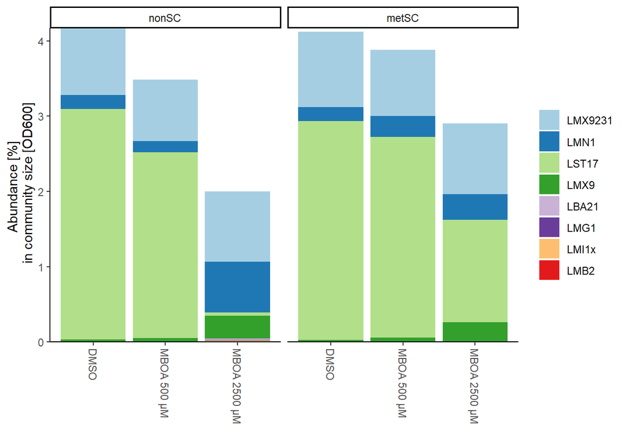